# Statistical Computing from Scratch

vincentole

# Statistical Computing

In this project we look at some methods and tools to perform statistical computing.  
We will therefore create different optimization, simulation and integration algorithms from scratch.

```r
# Load Packages
require(tidyverse)
```

```r
require(ggplot2)
```

# Part I - Optimization

In this part we will build algorithms to solve the Fréchet distribution.

```r
# Data:
#install.packages("evd")
require(evd)
n = 50
set.seed(656)
data = rfrechet(n, shape=1.8)
```

## 1. Data/Model inspection

First we define the log-likelihood function and the first and second order derivative. We will need these for some of the optimization algorithms.

We then take a look at the sample from the Fréchet distribution.

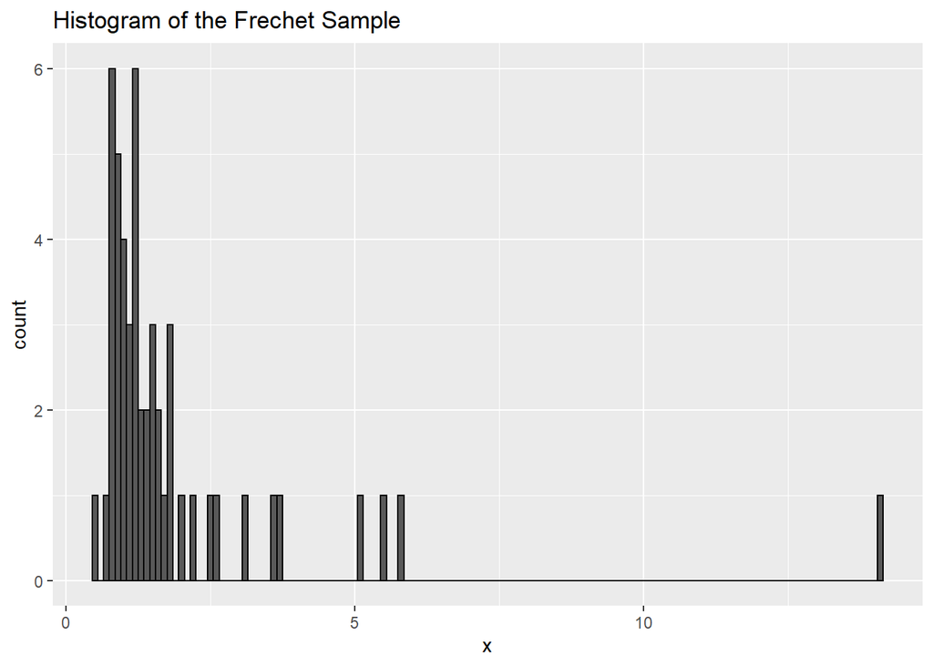

```r
# Log-likelihood function
ll <- function(alpha, n, data){ n * log(alpha) - (alpha + 1) * sum(log(data)) - sum(data^(-alpha))}
g <- function(alpha){ll(alpha, n = n, data = data)}

# First derivative of log-likelihood function
ll_prime <- function(alpha, n, data){ n/alpha - sum(log(data)) + sum(data^(-alpha) * log(data))}
g_prime <- function(alpha){ll_prime(alpha, n = n, data = data)}

# Second derivative of log-likelihood function
ll_2prime <- function(alpha, n, data){-n/alpha^2 - sum(data^(-alpha) * log(data)^2)}
g_2prime <- function(alpha){ll_2prime(alpha, n = n, data = data)}

# Plotting a histogram of the sample data
ggplot() +
  geom_histogram(aes(x = data), binwidth = 0.1, color = 'black') +
  labs(title = 'Histogram of the Frechet Sample', x = 'x')
```

We then generate a grid to plot the target function and its first derivative. From the plot we can see that the maximum should be around $x \approx 2.3$.

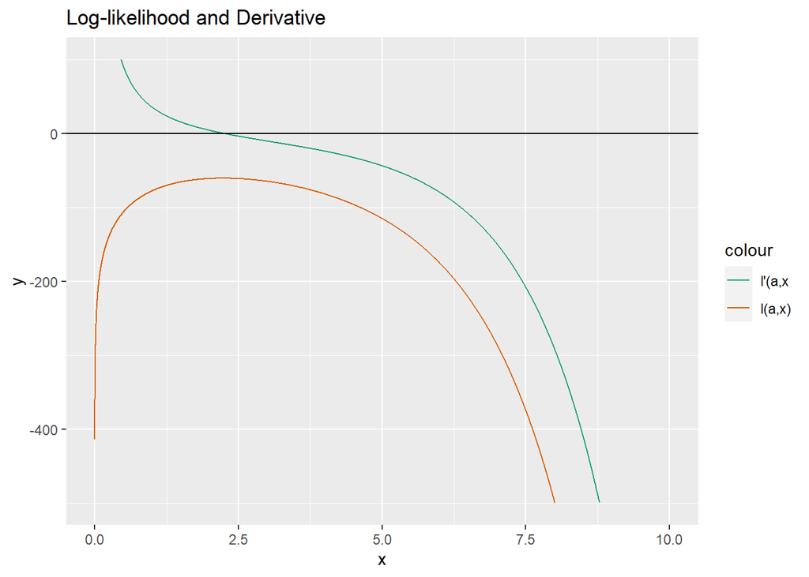

```r
# Generate numbers for the plot
x_grid <- seq(0.001,10,0.001)
g_grid <- c()
g_prime_grid <- c()

for(i in 1:length(x_grid)){
  g_grid[i] <- g(x_grid[i])
  g_prime_grid[i] <- g_prime(x_grid[i])
}

# Plotting ll and ll prime
ggplot() +
  ylim(-500, 100) +
  geom_line(aes(x = x_grid, y = g_grid, color = 'l(a,x)')) +
  geom_line(aes(x = x_grid, y = g_prime_grid, color = 'l\'(a,x')) +
  geom_hline(yintercept = 0) +
  labs(title = 'Log-likelihood and Derivative', x = 'x', y = 'y') +
  scale_color_brewer(palette="Dark2")
```

## 2. Bisection Method

First, we have to initilize some starting values.

```r
# Setting up starting values
start_time_bisec <- Sys.time() # init time benchmark
a <- 0.5                       # starting left value
b <- 4                         # starting right value
x <- NULL                      # init x
x[1] <- (b-a) / 2 + a          # starting midpoint
i <- 1                         # init iterations
```

We then define the search algorithm.

```r
# Search algorithm
while(TRUE){
  # Check left or right
  if(g_prime(a) * g_prime(x[i]) < 0){b = x[i]}
  else                              {a = x[i]}
  x[i+1] = a + (b-a) / 2

  # Calculate convergence criteria
  conv_abs <- abs(x[i+1] - x[i])
  conv_rel <- abs(x[i+1] - x[i]) / (x[i] + .Machine$double.eps)
  g_p_x <- g_prime(x[i+1])

  # Check convergence criteria
  if(i > 100){print("Max itr reached, no convergence."); break}
  if(conv_rel < (1 * .Machine$double.eps)){cat("Relative convergence reached at x=", x[i+1]); break}
  if(conv_abs < (1 * .Machine$double.eps)){cat("Absolute convergence reached at x=", x[i+1]); break}

  # Increase iterations
  i <- i + 1
}
```

```
## Relative convergence reached at x= 2.231775
```

```r
end_time_bisec <- Sys.time()                     # end time benchmark
time_bisec <- end_time_bisec - start_time_bisec  # computation time for bisec

# Output
x_bisec <- x[length(x)]                          # final x value
y_bisec <- g(x[length(x)])                       # final g(x) value
prime_bisec <- g_prime(x[length(x)])             # final g' value
i_bisec <- i                                     # total iterations

# Absolute convergence, with [1] = NA because diff() drops first element
eps_bisec <- c(NA, abs(diff(x)))
```

Finally we plot our results.

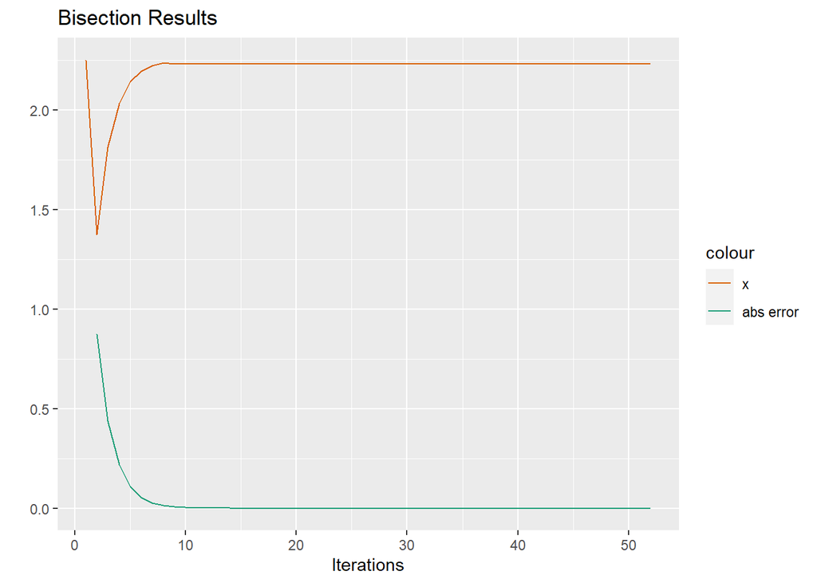

```r
# Plotting bisec results
ggplot() +
  geom_line(aes(x = 1:length(x), y = x, color = 'x')) +
  geom_line(aes(x = 1:length(eps_bisec), y = eps_bisec, color = 'abs error')) +
  xlim(1,52) +
  labs(title = 'Bisection Results', x = 'Iterations', y = '') +
  guides(color = guide_legend(reverse = TRUE)) +
  scale_color_brewer(palette="Dark2")
```

## 3. Newton’s Method

Next we use the Newton’s method, which should be much faster than the bisection method, because it uses second order information.

First, we have to initialize the starting values.

```r
start_time_newton <- Sys.time() # init time benchmark
x_start <- 2.25                 # starting value
x <- c()                        # reset x
x[1] <- x_start                 # init x
i <- 1                          # init iterations
```

We then define the algorithm.

```r
# Search algorithm
while(TRUE){
  x[i+1] <- x[i] - (g_prime(x[i]) / g_2prime(x[i]))

  # Calculate convergence criteria
  conv_abs <- abs(x[i+1] - x[i])
  conv_rel <- abs(x[i+1] - x[i]) / (x[i] + .Machine$double.eps)
  g_p_x <- g_prime(x[i+1])

  # Check convergence criteria
  if(i > 100){print("Max itr reached, no convergence."); break}
  if(conv_rel < (1 * .Machine$double.eps)){cat("Relative convergence reached at x=", x[i+1]); break}
  if(conv_abs < (1 * .Machine$double.eps)){cat("Absolute convergence reached at x=", x[i+1]); break}

  # Increase iterations
  i <- i + 1
}
```

```
## Relative convergence reached at x= 2.231775
```

```r
end_time_newton <- Sys.time()                      # end time benchmark
time_newton <- end_time_newton - start_time_newton # computation time for newton

# Output
x_newton <- x[length(x)]                           # final x value
y_newton <- g(x[length(x)])                        # final g(x) value
prime_newton <- g_prime(x[length(x)])              # final g' value
i_newton <- i                                      # total iterations

# Absolute convergence, with [1] = NA because diff() drops first element
eps_newton <- c(NA, abs(diff(x)))
```

Finally, we plot the results. We can see, that the convergence is much faster with the Newton’s method.

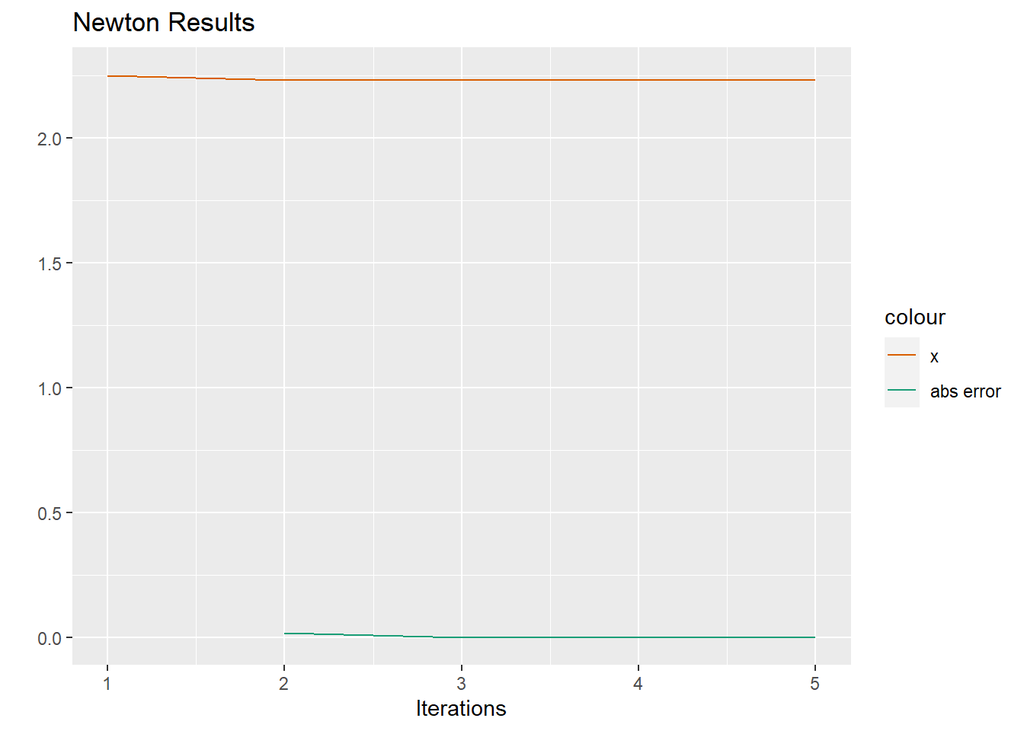

```r
# Plotting newton results
ggplot() +
  geom_line(aes(x = 1:length(x), y = x, color = 'x')) +
  geom_line(aes(x = 1:length(eps_newton), y = eps_newton, color = 'abs error')) +
  xlim(1,5) +
  labs(title = 'Newton Results', x = 'Iterations', y = '') +
  guides(color = guide_legend(reverse = TRUE)) +
  scale_color_brewer(palette="Dark2")
```

## 4. Algorithm Comparison

We now compare the maximum computed, the iterations needed, and the computation time for both methods. As we can see, both methods were able to find the maximum. The bisection method needs `52` iterations, while the Newton’s method only needs 4 to reach the convergence criteria. Since the task was relatively easy the computation time is almost identical.

```r
# Bisection - format output for readability
output_bisec <- c(format(round(y_bisec, 2), nsmall = 0),
                  format(round(i_bisec, 2), nsmall = 0),
                  format(round(time_bisec, 4), nsmall = 0))

# Newton - format output for readability
output_newton <- c(format(round(y_newton, 2), nsmall = 0),
                   format(round(i_newton, 2), nsmall = 0),
                   format(round(time_newton, 4), nsmall = 0))

# Model type column
model_type <- c("Bisection", "Newton")

# Final Output Matrix/Tibble
output_matrix <- as_tibble(cbind(model_type, rbind(output_bisec, output_newton)))
names(output_matrix) <- c("Model Type", "Max Value", "Iterations", "Computation Time")
output_matrix
```

| Model Type | Max Value | Iterations | Computation Time |
| --- | --- | --- | --- |
| Bisection | -60.75 | 52 | 0.044 secs |
| Newton | -60.75 | 4 | 0.048 secs |

# Part II - Integration

We now look at some methods for computational integration.

## 1. Monte Carlo

We start with the simple to implement Monte Carlo integration.

For this example we want to find $E(h(X))$ with $h(x) = \frac{x}{1-e^x}$, where X is distributed standard normal.

```r
# Problem definition
x <- rnorm(50000)    # sample of x, with n = 50,000
h <- x / (1-exp(x))  # h(x) of sample

# Monte Carlo Estimates
mu_hat <- mean(h)
se_mc <- sd(h) / sqrt(50000)
ci_mc <- c(mu_hat - 1.96*se_mc, mu_hat + 1.96*se_mc)

# Output
cat("Monte Carlo Estimate of mu is:\n", mu_hat, "\n\n",
    "Monte Carlo Estimate SE and CI(95%) are:\n",
    se_mc, "[",
    format(round(ci_mc[1],3), nsmall = 3),",",
    format(round(ci_mc[2],3), nsmall = 3), "]",  "\n")
```

```
## Monte Carlo Estimate of mu is:
##  -1.081466
##
##  Monte Carlo Estimate SE and CI(95%) are:
##  0.002286737 [ -1.086 , -1.077 ]
```

## 2. Importance Sampling

Next we will see how we can use importance sampling for computational integration.

For this example we want to find $\sigma^2 = E(X^2)$.  
The density of X is proportional to $exp(-\frac{|x|^3}{5})$.

Since we only have the kernel of the pdf given, we will use standardized weights.

```r
# Problem definition
f <- function(x){exp( -abs(x)^3 / 5)} # define f(x)
x <- rnorm(50000)                     # draw sample from g(x)
w_star <- f(x) / dnorm(x)             # compute weights

# Standardize weights, to cancel out c, since only the kernel of the pdf is given
w <- w_star / sum(w_star)

# Compute sigma squared hat
sig_sq_hat <- sum(x^2*w)

se_is <- sqrt(sum( w^2 * (f(x) - sig_sq_hat)^2 ))
ci_is <- c(sig_sq_hat - 1.96*se_is, sig_sq_hat + 1.96*se_is)

# Output
cat("Importance Sampling Estimate of sigma square is:\n", sig_sq_hat, "\n\n",
    "Importance Sampling Estimate SE and CI(95%) are:\n",
    se_is, "[",
    format(round(ci_is[1],3), nsmall = 3),",",
    format(round(ci_is[2],3), nsmall = 3), "]",  "\n")
```

```
## Importance Sampling Estimate of sigma square is:
##  1.094088
##
##  Importance Sampling Estimate SE and CI(95%) are:
##  0.001897646 [ 1.090 , 1.098 ]
```

# Part III - MCMC Simulation

In this part we use the Metropolis Hasting algorithm to sample from a Gaussian mixture distribution.

## 1. Set the target function

First we define out target function and the sampling/proposal function.

```r
# Set target function
target <- function(x){
  0.2 * dnorm(x, 2, 1.8^2) + 0.8 * dnorm(x, 5, 4^2)
}

# Set sampling function
proposed <- function(x){rnorm(1, x, 1.5^2)}
```

We then define the Metropolis Hasting algorithm.

```r
# Metropolis Hasting function
metr_hast <- function(x_start){

  # Set starting value
  x <- x_start

  # Start algorithm loop
  for(i in 1:5000){
    x_new <- proposed(x[i])
    ratio <- target(x_new) / target(x[i])
    x[i+1] <- ifelse(runif(1) < ratio, x_new, x[i])
  }

  # Plot sample histogram and target density
  plot1 <- ggplot() +
    geom_histogram(aes(x = x, y = ..density..), color = 'black', fill = 'gray', bins = 50) +
    geom_function(fun = target, color = 'brown1', size = 0.8) +
    labs(title = 'Metropolis-Hastings - Sample Hist and Target Density', y = 'density', x = 'x')

  # Plot path of x
  plot2 <- ggplot() +
    geom_line(aes(x = 1:length(x), y = x)) +
    labs(title = 'Metropolis-Hastings - Path of x', x = 'iterations', y = 'x')

  # Output of function
  output <- list(x, plot1, plot2)

  return(output)
}
```

It is always a good idea to use different starting values for most numerical optimization and integration/simulation algorithms. This is because there is a chance that the algorithm gets stuck in a local optimum or neighborhood, that depends on the starting values.

We therefor use different starting values.

```r
# Store MH runs with different starting values (0, 4, 10)
mh_start_0 <- metr_hast(0)
mh_start_4 <- metr_hast(4)
mh_start_10 <- metr_hast(10)
```

## 2. Results

### Plot Path of x

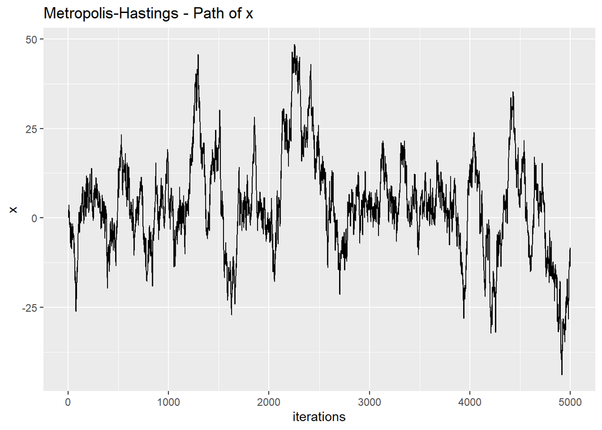

```r
# Plot path of x
mh_start_0[3]
```

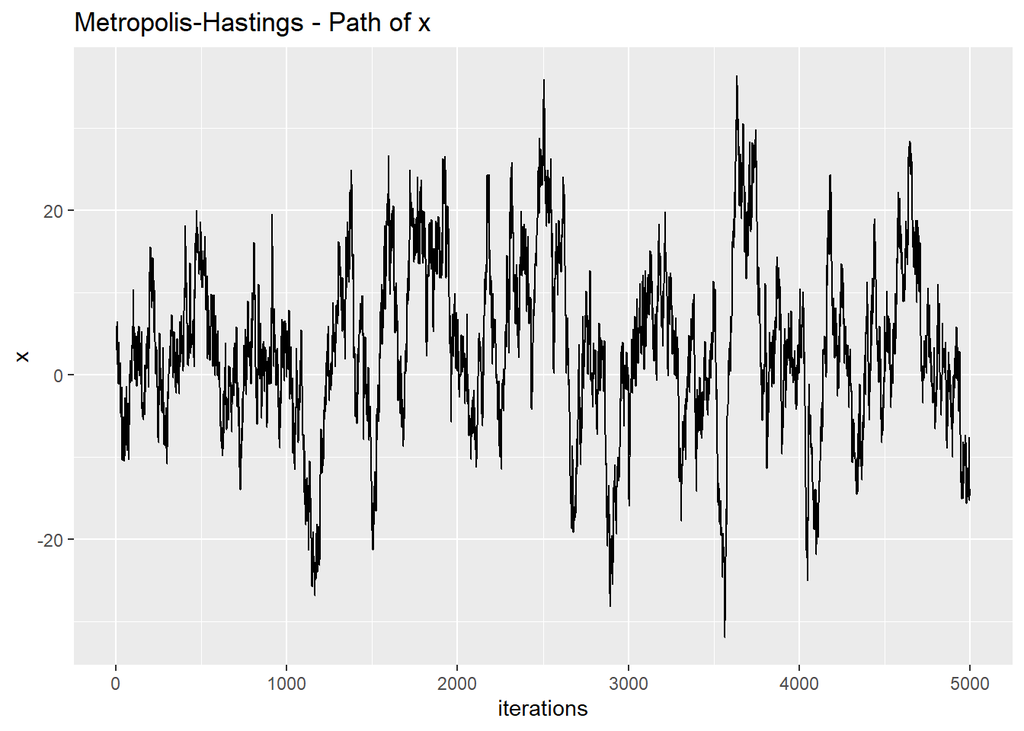

```r
mh_start_4[3]
```

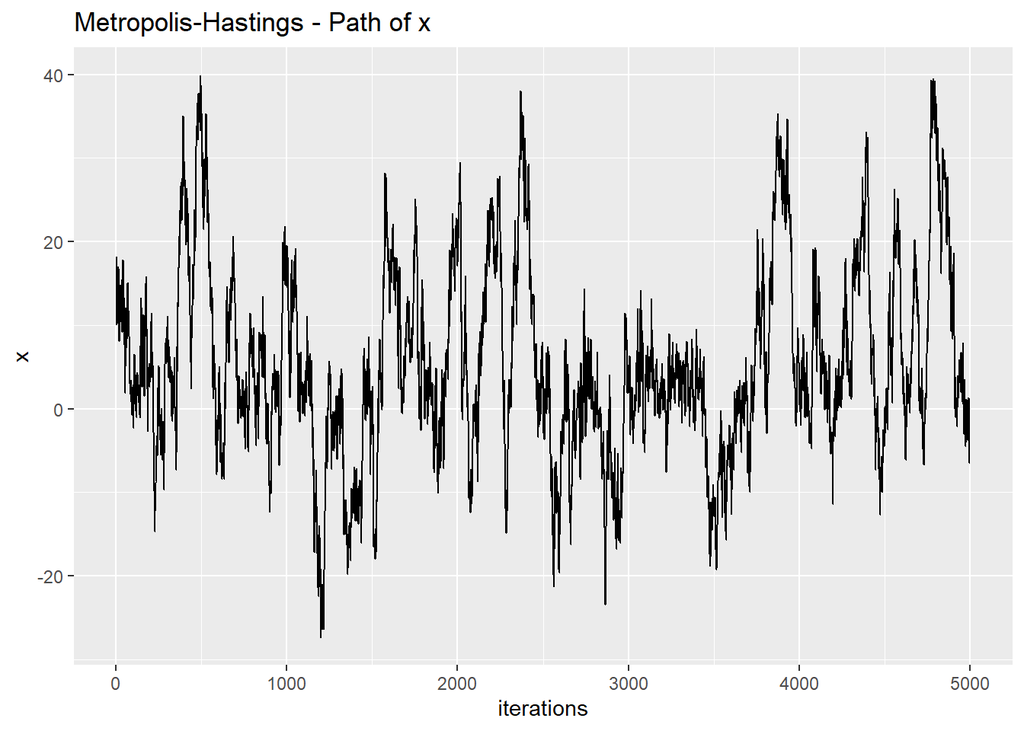

```r
mh_start_10[3]
```

### Plot Sample Hist and Target Density

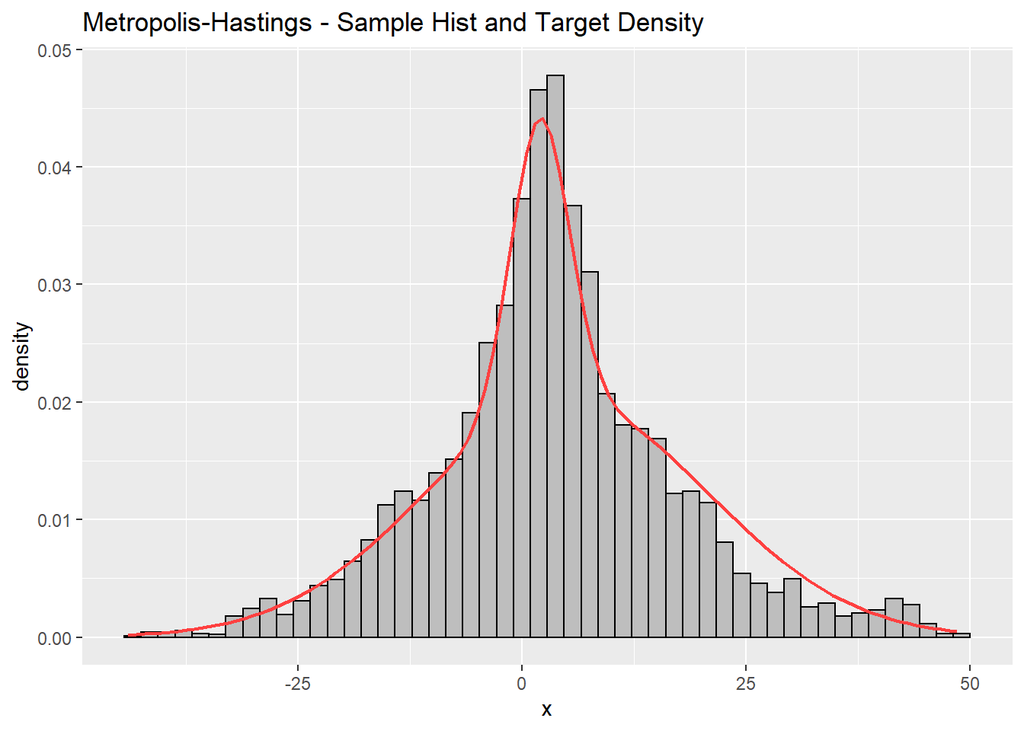

```r
# Plot sample hist and target density
mh_start_0[2]
```

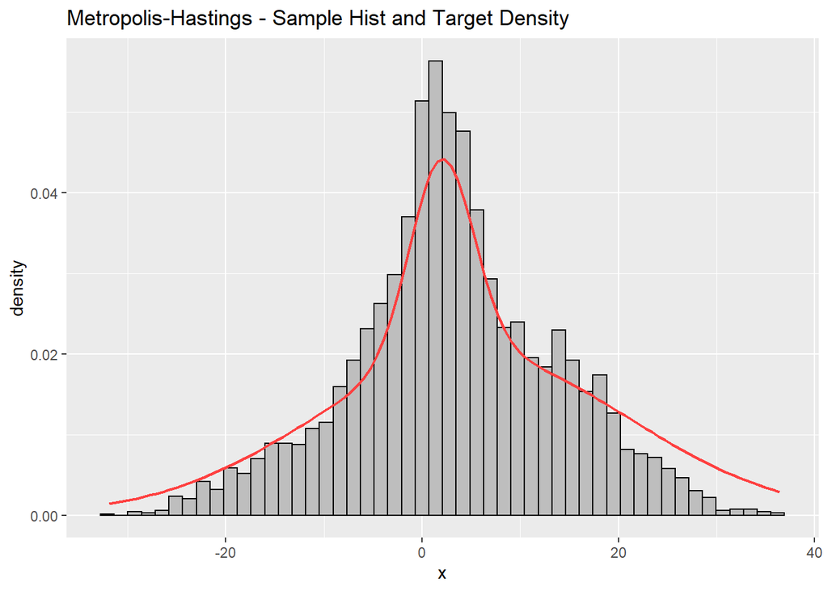

```r
mh_start_4[2]
```

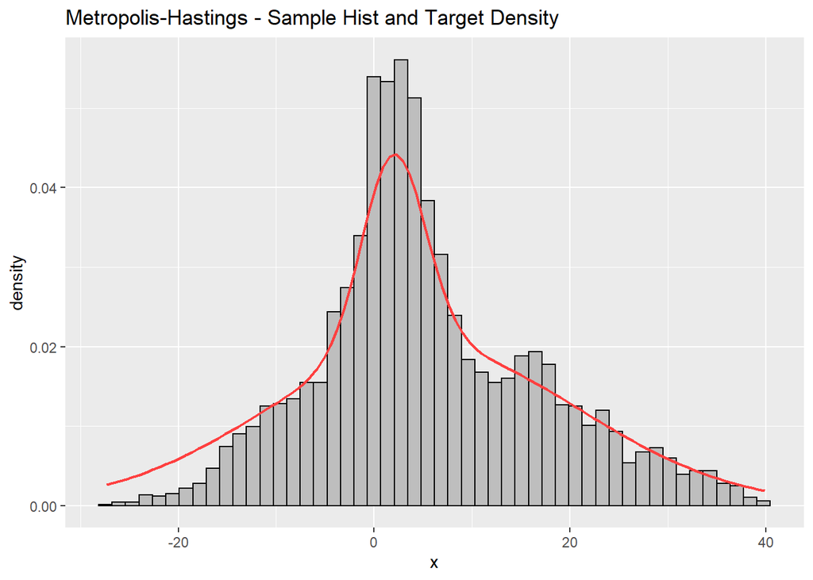

```r
mh_start_10[2]
```

## 3. Improve the MH MCMC

From the plot we can see that the sample distribution is not optimal. We can widen the variance of the proposal distribution to explore a greater range of the target function.

```r
# Widen variance of proposal distribution to explore quicker
proposed <- function(x){rnorm(1, x, 3^2)}

# Store MH runs with different starting values (0, 4, 10)
mh2_start_0 <- metr_hast(0)
mh2_start_4 <- metr_hast(4)
mh2_start_10 <- metr_hast(10)
```

### Plot Path of x

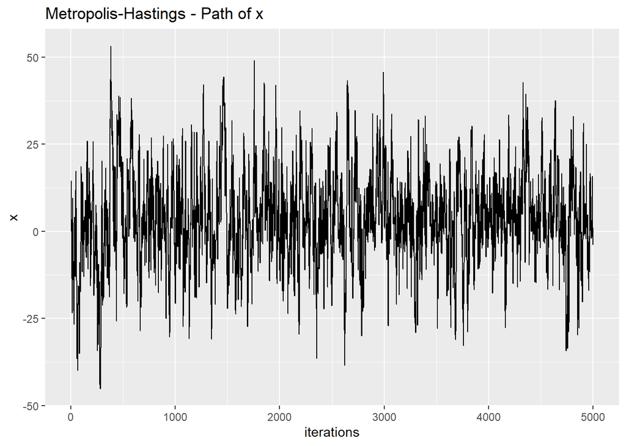

```r
# Plot path of x
mh2_start_0[3]
```

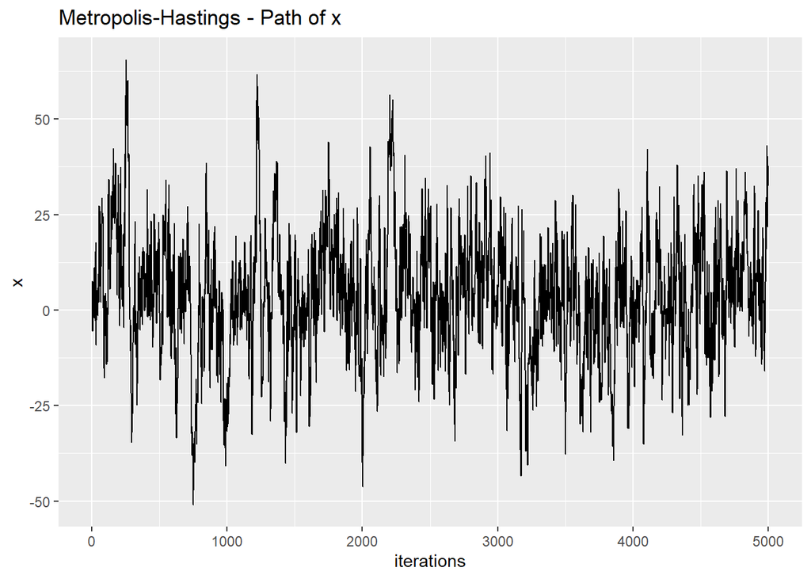

```r
mh2_start_4[3]
```

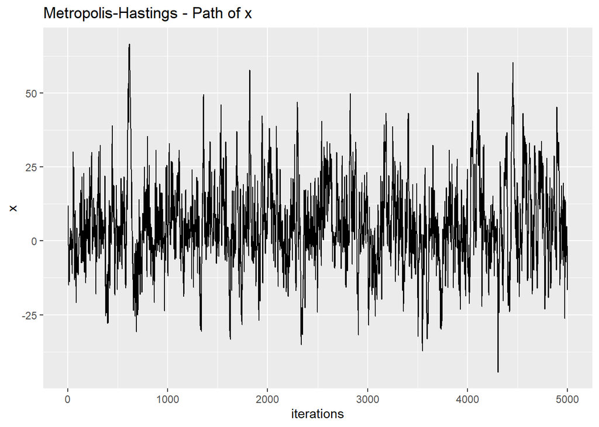

```r
mh2_start_10[3]
```

### Plot Sample Hist and Target Density

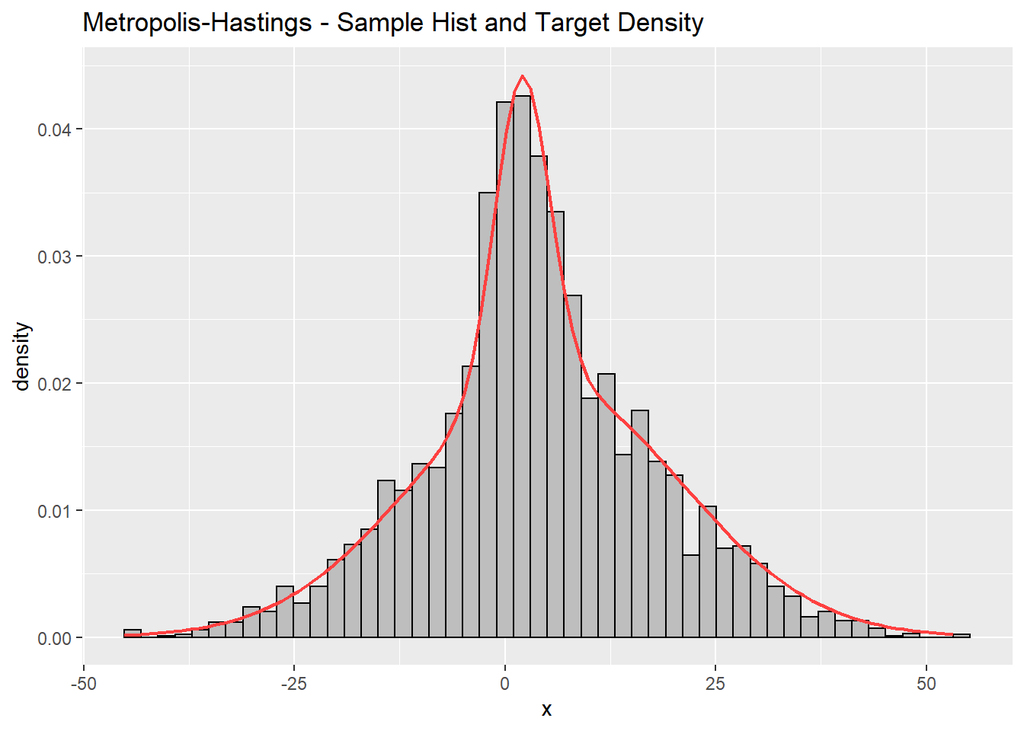

```r
# Plot sample hist and target density
mh2_start_0[2]
```

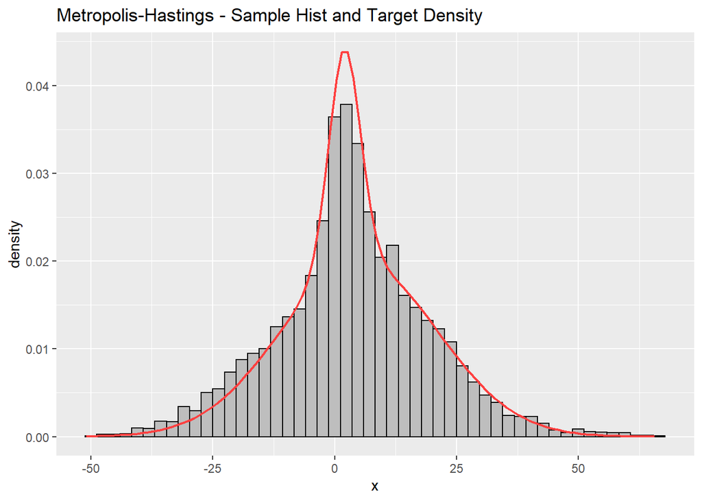

```r
mh2_start_4[2]
```

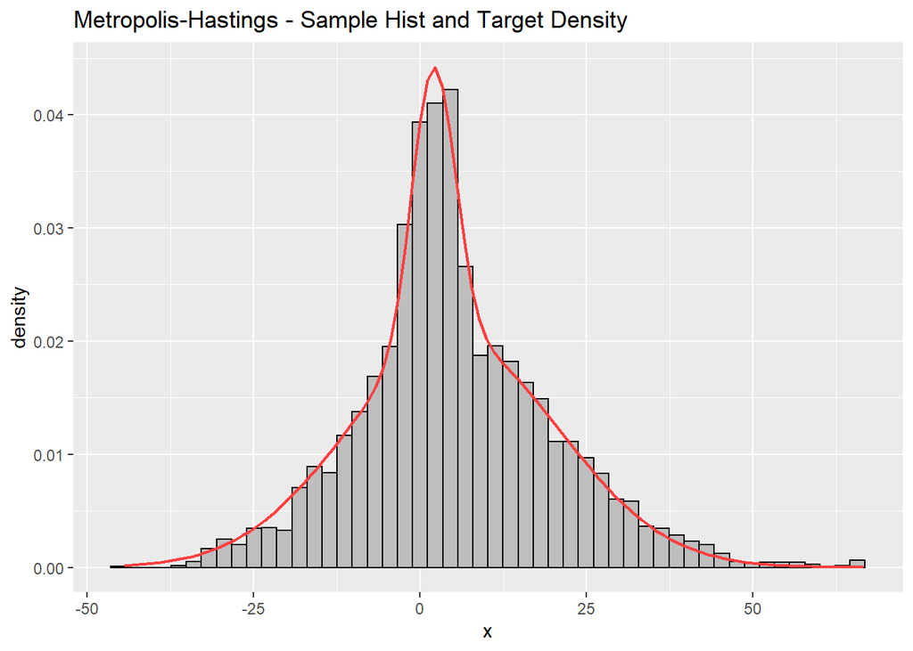

```r
mh2_start_10[2]
```

As we can see from the plots, now the sample distribution fits much closer to the target distribution.